# S1_Informe

24 de junio del 2022

**Principales factores que influyen en la compra de dentífricos en las personas de 18 a 30 años, en Lima Metropolitana durante el primer semestre del 2022.**

[figure not shown]

## I. Introducción

### 1.1 Relevancia

Según la ingeniera civil de industrias Denisse Faúndez “La familia es la unidad social de mayor influencia en la conducta de sus miembros, particularmente en lo que tiene relación a conducta de consumo”(2018). En base a ello resulta factible estudiar dicha influencia en jóvenes universitarios en el caso de la compra de pasta dental.

### 1.2 Planificación

Para organizar la realización del proyecto se elaboró un diagrama de Gantt, de manera que, se pueda apreciar graficamente las actividades planeadas y el tiempo que se dedicará a su elaboración. Se utilizó la aplicación Miro.com para la elaboración del diagrama:

[figure not shown]

### 1.3 Antedecentes

### FACUS GROUP

- Análisis y Resultados del FOCUS GROUP para pastas dentales, es un informe estadístico desarrollado en la ciudad de Piura que pretende determinar la preferencia que presenta una marca de dentífricos respecto a otra; y las ventajas y desventajas que se encuentran en cada una, a través de un plan de marketing denominado FOCUS GROUP con la finalidad de recopilar información de un segmento representativo del mercado de las pastas dentales, para ello se tomó una muestra de 10 participantes, 4 mujeres y 6 varones estudiantes de la universidad Alas Peruanas de entre 17 y 22 años, tras dicho estudio se concluyó que la pasta más asequible por su publicidad, variedad y sabor fue Colgate con un 40% .

Alberca, K., Jabo, E., Jiménez Y., Marrufo N., Rivas E & Sánchez W. (2018). Análisis y resultados del focus group para pastas dentales. Recuperado el 02 mayo 2022, de: [link](https://www.academia.edu/36904076/Focus_Group_-_Pastas_Dentales)

### Compañia peruana de estudios de mercado y opinión pública

- La compañía peruana de estudios de mercado y opinión pública realizó un estudio de mercado con una muestra de 2542 personas de 11 años a más en Lima Metropolitana, a partir de una base de datos única, analizando el consumo de productos, marcas y servicios en forma interrelacionada con el consumo de medios y con aspectos cualitativos del consumidor. Concluyendo que un 41.4% utilizaba una pasta dental de marca Kolinos, el 37.5% de marca Colgate, el 36.6% de marca Dento y que el 56% de la población adquiere este producto en bodegas.

Compañía peruana de estudios de mercado y opinión pública. (2007). Multimix de consumo productos de cuidado personal: crema dental, champú [link](https://cpi.pe/images/upload/paginaweb/archivo/23/200702_INFORME_CHAMPU_CREMADENTAL.pdf)

### Como influye la públicidad en el uso de las pastas dentales

- En la ciudad de México, se realizó un estudio de la influencia de la publicidad en el uso de las pastas dentales con una muestra de 120 consumidores distribuida en tres diferentes tipos de tiendas comerciales cada una con un enfoque distinto de clase social. Tras el estudio se encontró una prevalencia del 90% donde la pasta dental “COLGATE” fué la de mayor consumo, encontrando sólo un 10% de otras. Siendo así que un 41% de las personas encuestadas influye mucho la publicidad para el consumo de las pastas dentales. Por ello se concluyó que en la mayoría de la población que ve la televisión la publicidad es uno de los principales factores determinantes para el uso de la pasta dental así como el precio y la calidad han influido en la preferencia de su compra.

Almanza, I., Bravo, Y., Flores, G., Godinez, D & Trejo, N. (S. F). Cómo influye la publicidad en el uso de las pastas dentales [link](https://cpi.pe/images/upload/paginaweb/archivo/23/200702_INFORME_CHAMPU_CREMADENTAL.pdf)

### 1.4 Contexto

En la actualidad, existen diversas marcas que se enfocan en la salud dental por lo que existe una gran variedad de opciones tanto en marcas nacionales como internacionales que cuentan con una fuerte presencia en el mercado peruano. Dentro de estas marcas tenemos a Colgate, Oral B, Kolynos, Binaca, Corega y Dento. En primer lugar, tenemos como marca nacional Dento que es una de las mejores opciones tanto en calidad y precio, puesto a que suele ser comprada por ser factible y estar al alcance de todos. En segundo lugar, tenemos a Colgate que es reconocida por ser una marca internacional y por el tipo de publicidad y marketing que ofrece. Asimismo, tenemos a Oral B que es competencia directa de Colgate, ambas marcas están muy bien posicionadas en el mercado y suelen tener un alto porcentaje de venta por lo que constantemente buscan mejorar. Por otro lado, tenemos a las marcas Kolynos, Binaca que son reconocidas en menor escala que Colgate y Oral B pero al igual que la marca Dento cuenta con precios más accesibles.

[figure not shown]

### 1.5 Preguntas de investigación

[output not shown]

### 1.6 Objetivos:

- Determinar las marcas de dentífricos que tuvieron un alto índice de consumo por parte de la población de Lima metropolitana.
- Analizar las preferencias de nuestra población de Lima metropolitana al adquirir un dentífrico.
- Identificar los tipos de dentífricos que prefieren las personas de 18 a 30 años en Lima metropolitana.
- Determinar los factores que influyen en la selección de las marcas de dentífricos por parte de la población de Lima metropolitana.
- Verificar a través de la data las variables que determinan la selección del uso de distintos dentífricos por parte de nuestra población en Lima metropolitana.
- Clasificar las marcas de dentífrico más consumidas hasta los menos consumidos por parte de la población de 18 a 30 años en Lima metropolitana.
- Identificar la frecuencia de limpieza bucal de nuestra población en Lima metropolitana.

## Datos

### 2.1 Proceso de recolección de datos

Dentro de la recolección de datos optamos por realizar una encuesta en donde se obtuvo información detallada sobre nuestro tema. Asimismo, esta información es de gran ayuda debido a que nuestro proyecto depende directamente de esta data. En primer lugar, los métodos empleados para la recolección de datos fue distribuirla vía Whatsapp, subirla a un excel que nos brindó la organización SWE y pedirles presencialmente a los alumnos de UTEC que nos apoyaran completando la encuesta. Por otro lado, seleccionamos estos métodos ya que se nos hace más factible al momento de recolectar los datos debido a que no podríamos enviarla vía correo debido a que estaba prohibido. En segundo lugar, optamos por delimitar el tema para así abarcar un tema específico y que no sea generalizado. De igual manera, al haber escogido a personas que cumplan con las caracteristicas entre 18 a 30 y que sean residentes de lima metropolitano para poder tener variables convenientes para nuestro estudio.

[Link de Encuesta](https://forms.gle/Ex5UpkCmsYh2Y8KD7)

### 2.4 Muestreo

Muestreo no aleatorio intensional, Mediante este método, nos encaragamos de elegir segun nuestros alcances a los sujetos que formaran parte de nuestra muestra.

### 2.5 Variables

| **Descripción** | **Variable** | **Tipo de Variable** | **Restricciones** |
| --- | --- | --- | --- |
| Género con el que se identifica el consumidor | Género | Categorica ordinal | Masculino, Femenino |
| Lugar donde recide el consumidor en Lima Metropolitana | Residencia | Categorica ordinal | Lima norte, este, moderna, sur, callao, antigua |
| Situación dentro del ambito familiar actualmente | Vive con padres | Categorica ordinal | Si, No |
| Situacion de compra de una marca de dentrificos | Compra personal | Categorica ordinal | Si, No |
| Nivel de educación culminada por el consumidos | Instrucción | Categorica ordinal | Secundaria completa, Superior Universitario completo/incompleto, Superior Técnico completo/incompleto |
| Marca de dentrifico utilizado actualmente por el consumidor | Marca | Categorica nominal |  |
| Años cumplidos de los consumidores | Edad | Numérica Discreta | Un real positivo entre 18 y 30 |
| Frecuencia de veces con las que un consumidor de dentrificos se cepilla los dientes | Cepillado dental diario | Numérica Continua | Un real positivo |

### 2.6 Limpieza de datos

**Instalando y cargando librerias**

```r
# list.of.packages <- c("readr", "knitr","expss","DT", "tidyr","flextable","moments","janitor","dplyr","ggplot2", "ggpubr","gmodels","stringr","modeest")
# new.packages <- list.of.packages[!(list.of.packages %in% installed.packages()[,"Package"])]
# if(length(new.packages)) install.packages(new.packages)
```

```r
library(stringr)
library(readr)
library(knitr)
library(expss)
library(tidyr)
library(flextable)
library(moments)
library(janitor)
library(dplyr)
```

```r
library(ggplot2)
library(ggpubr)
theme_set(theme_pubr())
library(gmodels)
library(modeest)
```

**Lectura de Data:**

```r
Encuesta <- read_csv("Encuestas.csv")
```

**Eliminacion de columna inecesaria**

```r
Encuesta %>% select(-1) -> Encuesta # Se elimina la columna que indica la hora de llenado de la encuesta
```

**Renombrar las variables**

```r
Encuesta <- rename(Encuesta, Edad = 'Edad (Años cumplidos)  Ejemplo.- 18', Nivel_de_instrucción = "Nivel de instrucción", Residencia = "Lugar de residencia", Vive_Con_Padres = "¿Actualmente vives con tus padres?", Marca_Dentrifico = "¿Qué dentífrico utilizas con más frecuencia?", Compra_Personal = "¿Realizas personalmente la compra de tu dentífrico?", Motivo = "¿Cuáles son los motivos que predominan al momento de decidir que dentífrico comprar?", Costo = "¿Cuál es el costo del dentífrico que usas?(ejemplo: S/. 1)", Cepillado_dental_diario = "¿Cuántas veces al día te cepillas los dientes?", Cambio_en_dentrifico = "¿En algún momento cambiaste o consideraste cambiar de dentífrico?" )
```

**Verificando si se realizo el cambio de variable**

```r
names(Encuesta)
```

```
##  [1] "Edad"                    "Género"
##  [3] "Nivel_de_instrucción"    "Residencia"
##  [5] "Vive_Con_Padres"         "Marca_Dentrifico"
##  [7] "Compra_Personal"         "Motivo"
##  [9] "Costo"                   "Cepillado_dental_diario"
## [11] "Cambio_en_dentrifico"
```

**Verificar que tipos de datos tenemos por variable**

```r
summary(Encuesta)
```

```
##       Edad          Género          Nivel_de_instrucción  Residencia
##  Min.   :18.00   Length:207         Length:207           Length:207
##  1st Qu.:18.00   Class :character   Class :character     Class :character
##  Median :20.00   Mode  :character   Mode  :character     Mode  :character
##  Mean   :20.06
##  3rd Qu.:21.00
##  Max.   :28.00
##  Vive_Con_Padres    Marca_Dentrifico   Compra_Personal       Motivo
##  Length:207         Length:207         Length:207         Length:207
##  Class :character   Class :character   Class :character   Class :character
##  Mode  :character   Mode  :character   Mode  :character   Mode  :character
##
##
##
##      Costo       Cepillado_dental_diario Cambio_en_dentrifico
##  Min.   : 1.50   Min.   : 1.000          Length:207
##  1st Qu.: 6.10   1st Qu.: 2.000          Class :character
##  Median :12.00   Median : 2.000          Mode  :character
##  Mean   :11.66   Mean   : 2.454
##  3rd Qu.:16.00   3rd Qu.: 3.000
##  Max.   :75.00   Max.   :16.000
```

**Limpiando Datos**

```r
## Cambiamos una respuesta larga por una mas corta

Encuesta %>% mutate(Motivo =
                   ifelse(Motivo =="Identificar la crema dental con la que me siento comoda que es colgate total 12","Comodidad con el dentrífico", Motivo)) -> Encuesta

table(Encuesta$Motivo)
```

```
##
##                               Calidad Cantidad de fluoruro en el dentífrico
##                                     2                                     1
##           Comodidad con el dentrífico                 Decisiones familiares
##                                     1                                    48
##                                Dureza               El costo del dentífrico
##                                     1                                    39
##          La propaganda y el marketing         La recomendación de conocidos
##                                    44                                    65
##                            Odontólogo                                 Sabor
##                                     1                                     5
```

**Limpiando un dato incoherente en la variable motivo**

```r
filter(Encuesta, Encuesta$Motivo != "Dureza") -> Encuesta
```

**Eliminamos un dato absurdo en la variable cepillado al dia**

```r
filter(Encuesta, Encuesta$Cepillado_dental_diario != "16") -> Encuesta
```

**Eliminamos un dato absurdo en la variable costo**

```r
filter(Encuesta, Encuesta$Costo != 75 ) -> Encuesta
```

**Cambiamos el nombre de un dato erróneo**

```r
Encuesta %>% mutate(Marca_Dentrifico =
        ifelse(Marca_Dentrifico == "Colgate 12", "Colgate", Marca_Dentrifico
        )) -> Encuesta
```

# DESCRIPTORES NUMÉRICOS

## Variables categóricas:

El único descriptor númerico para estas variables tenemos la moda.

De las diversas variables categóricas se eligieron las 3 más importantes:

```r
cat('Moda en la marca de dentríficos: ',mfv(Encuesta$Marca_Dentrifico),'\n')
```

```
## Moda en la marca de dentríficos:  Colgate
```

```r
cat('Moda del lugar de residencia: ',mfv(Encuesta$Residencia),'\n')
```

```
## Moda del lugar de residencia:  Lima moderna
```

```r
cat('Moda del motivo por el cual compran un dentrífico: ',mfv(Encuesta$Motivo),'\n')
```

```
## Moda del motivo por el cual compran un dentrífico:  La recomendación de conocidos
```

## Variables numéricas:

Para estas variables no hay restricción en el uso de descriptores numéricos.

### Variable Edad:

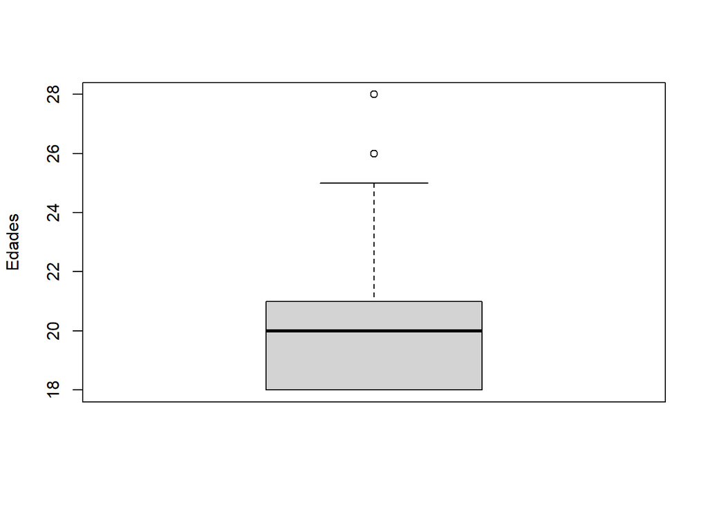

```r
boxplot(Encuesta$Edad, ylab = "Edades")
```

```r
cat('Moda: ',mfv(Encuesta$Edad),'\n' )
```

```
## Moda:  18
```

```r
cat('Mediana: ',median(Encuesta$Edad),'\n' )
```

```
## Mediana:  20
```

```r
cat('Media: ',mean(Encuesta$Edad),'\n')
```

```
## Media:  20.06373
```

```r
cat('Rango: ',range(Encuesta$Edad),'\n' )
```

```
## Rango:  18 28
```

```r
cat('Rango intercuartil: ',round(IQR(Encuesta$Edad),2),'\n')
```

```
## Rango intercuartil:  3
```

Interpretación: Se observa que hay datos atípicos y en su distribución de datos presenta un sesgo a la derecha debido a que la media es mayor a la mediana.

### Variable Costo:

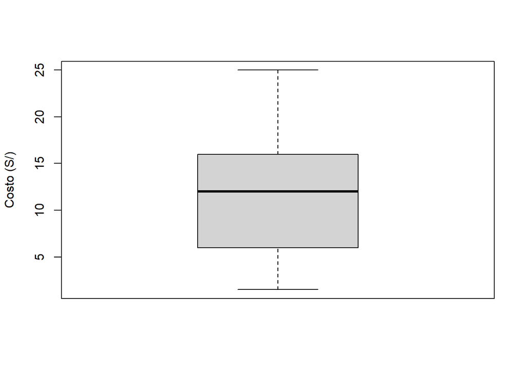

```r
boxplot(Encuesta$Costo, ylab = "Costo (S/)")
```

```r
cat('Moda: ',mfv(Encuesta$Costo),'\n' )
```

```
## Moda:  16
```

```r
cat('Mediana: ',median(Encuesta$Costo),'\n' )
```

```
## Mediana:  12
```

```r
cat('Media: ',mean(Encuesta$Costo),'\n')
```

```
## Media:  11.30348
```

```r
cat('Rango: ',range(Encuesta$Costo),'\n' )
```

```
## Rango:  1.5 25
```

```r
cat('Rango intercuartil: ',round(IQR(Encuesta$Costo),2),'\n')
```

```
## Rango intercuartil:  10
```

Interpretación: No existe datos atípicos para esta variable y en su distribución de datos presenta un sesgo hacía la izquierda debido a que la mediana es mayor que la media.

# DESCRIPTORES GRÁFICOS

- Objetivo 1:

### Determinar las marcas de dentífricos que tuvieron un alto índice de consumo por parte de la población de Lima metropolitana.

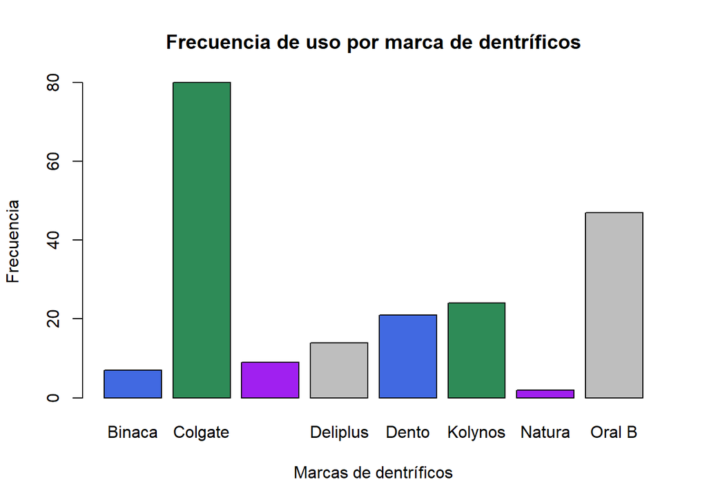

```r
barplot(table(Encuesta$Marca_Dentrifico),col=c("royalblue","seagreen","purple","grey"), main="Frecuencia de uso por marca de dentríficos",ylab="Frecuencia",xlab="Marcas de dentríficos")
```

Conclusión: Como podemos observar se ve que la marca que tiene un mayor índice de consumo en Lima Metroplitana es la marca Colgate, la segunda más consumida es la marca Oral B. Por último, la menos consumida es la marca Natura.

- Objetivo 2:

### Determinar los factores que influyen en la selección de las marcas de dentífricos por parte de la población de Lima metropolitana

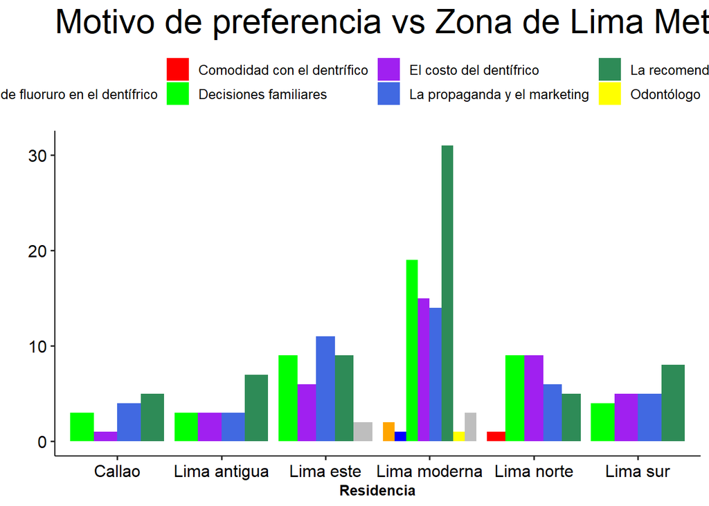

```r
g = ggplot(Encuesta, aes(Residencia, fill=Motivo) ) +
  labs(title = "Motivo de preferencia vs Zona de Lima Metropolitana")+ylab("") +
  theme(plot.title = element_text(size = rel(2), colour = "black"))

g+geom_bar(position="dodge") + scale_fill_manual(values = alpha(c("orange", "blue", "red", "green", "purple","royalblue","seagreen","yellow","grey"), 1)) +
  theme(axis.title.x = element_text(face="bold", size=10))
```

Conclusión: Se puede observar en el gráfico que las personas en Lima Moderna, Lima Antigua y Lima Sur las personas compran un dentrífico debido a la recomendación de sus conocidos. En Lima Este las peronas se ven influenciados por la propaganda y el marketing. Mientras que en Lima Norte es debido a decisones familiares y costo del dentrífico.

- Objetivo 3: ### Identificar los tipos de dentífricos que prefieren las personas de 18 a 30 años en Lima metropolitana.

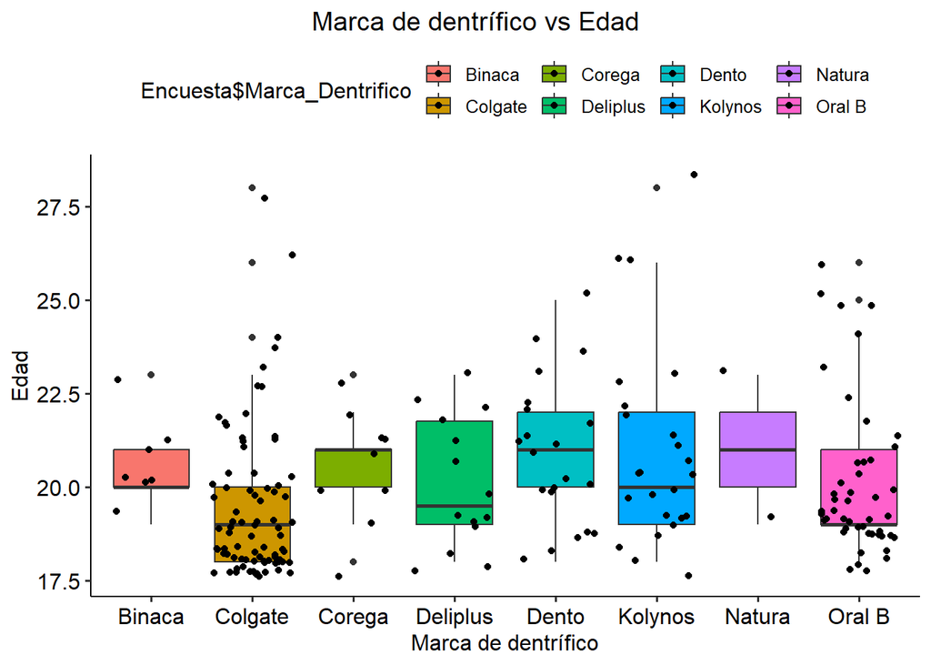

```r
qplot(Encuesta$Marca_Dentrifico, Encuesta$Edad, data=Encuesta, geom=c("boxplot","jitter"), fill=Encuesta$Marca_Dentrifico, xlab = "Marca de dentrífico", ylab = "Edad", main = "                             Marca de dentrífico vs Edad")
```

Conclusión: Se observa en la gráfica que la marca Colgate es usada mayormente por las personas entre 18 a 20 años, se puede observar que presenta un sesgo hacia la derecha, además de presentar datos atípicos.

- Objetivo 4: ### Verificar a través de la data las variables que determinan la selección de distintos dentífricos de nuestra población de acuerdo a su género en Lima metropolitana.

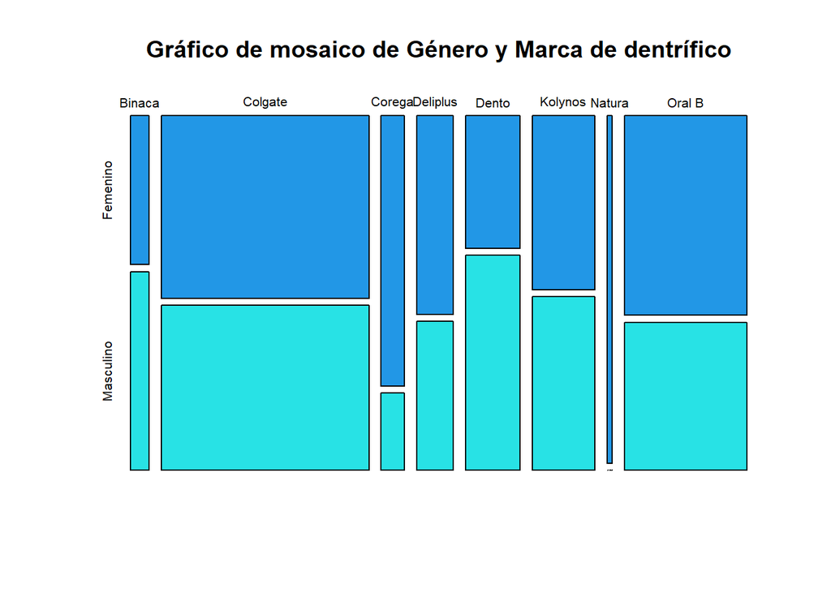

```r
tabla2 <- table(Encuesta$Marca_Dentrifico,Encuesta$Género)
mosaicplot(tabla2, col = c(4:6), main = "Gráfico de mosaico de Género y Marca de dentrífico")
```

Conclusión: De acuerdo a la gráfica se puede observar que el género femenino prefiere comprar la marca Colgate y Oral B. Mientras que el género masculino prefiere la marca Dento y Binaca.

- Objetivo 5: ### Identificar el costo de acuerdo a la residencia de la población.

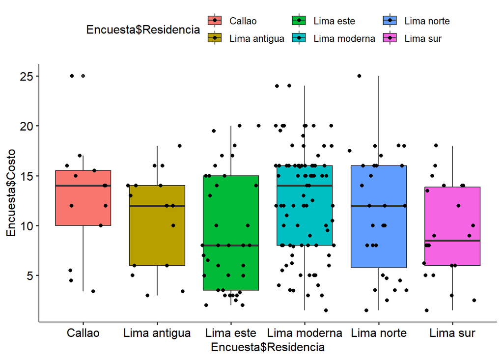

```r
qplot(Encuesta$Residencia, Encuesta$Costo, data=Encuesta, geom=c("boxplot","jitter"), fill=Encuesta$Residencia)
```